# Cats vs Dogs in the US

Katherine Blake, Jorge Diaz, Alejandro Medina and Mark Mueller

2023-09-27

## Introduction

**The data we are analyzing is in regards to pet ownership statistics in the United States. The data includes averages of cats and dogs within state households as well as pet owner’s devotion to their pets, whether the owners are willing to stay at a job they dislike for their pets, and whether the owner’s were willing to spend $4k to save their pets.**

```r
# loading in packages needed for the project
library(here) # used for finding the location of the data set file
```

```r
library(maps) # used for map visualization code
library(ggplot2) # used for ggplot
library(dplyr) # used to aid in functionality use of visualizations
# loading in the data as pet_data
pet_data = read.csv(here("DATA","pet-ownership-statistics-by-state_Group2.csv"))
```

## Initial Observations

```r
head(pet_data) # viewing the first six rows of data
```

```
##           state TotalHouseoldsPerc DogsPerc AvgNumDogs CatsPerc AvgNumCats
## 1       Wyoming               71.8     36.0        1.7     30.0        1.8
## 2 West Virginia               70.7     49.6        1.7     37.7        2.1
## 3      Nebraska               70.3     47.1        1.8     30.9        2.3
## 4       Vermont               70.0     28.3        1.3     44.6        1.3
## 5         Idaho               69.9     58.3        1.7     33.3        2.0
## 6       Indiana               69.2     49.4        1.6     37.5        1.9
##   DogDevotionScore StayedAtAJobTheyDislikedForDogPerc
## 1            25.53                                6.5
## 2            53.47                                8.0
## 3            10.12                                7.5
## 4            38.07                                6.0
## 5            32.33                                8.0
## 6            32.02                                7.5
##   WhoWouldSpend4kToSaveDogPerc
## 1                         37.0
## 2                         29.0
## 3                         25.5
## 4                         46.5
## 5                         27.5
## 6                         34.0
```

```r
dim(pet_data) # viewing the dimensions of the data
```

```
## [1] 49  9
```

```r
str(pet_data) # viewing the structure of the data
```

```
## 'data.frame':    49 obs. of  9 variables:
##  $ state                             : chr  "Wyoming" "West Virginia" "Nebraska" "Vermont" ...
##  $ TotalHouseoldsPerc                : num  71.8 70.7 70.3 70 69.9 69.2 69 65.5 65 64.7 ...
##  $ DogsPerc                          : num  36 49.6 47.1 28.3 58.3 49.4 51.6 51 47.7 47.2 ...
##  $ AvgNumDogs                        : num  1.7 1.7 1.8 1.3 1.7 1.6 1.8 2.1 1.8 1.6 ...
##  $ CatsPerc                          : num  30 37.7 30.9 44.6 33.3 37.5 34.8 29.1 28.4 27.1 ...
##  $ AvgNumCats                        : num  1.8 2.1 2.3 1.3 2 1.9 2.1 2 1.8 1.6 ...
##  $ DogDevotionScore                  : num  25.5 53.5 10.1 38.1 32.3 ...
##  $ StayedAtAJobTheyDislikedForDogPerc: num  6.5 8 7.5 6 8 7.5 11.5 6.5 5 11 ...
##  $ WhoWouldSpend4kToSaveDogPerc      : num  37 29 25.5 46.5 27.5 34 32.5 28.5 25.5 43.5 ...
```

**As we go through the nature of the data, we can clearly see the dimensions of the data being 49 observations against 9 variables. These variables are the State, Total Household percentage, Dogs Percentage, Average Number of Dogs, Cats percentage, Average Number of cats, Dogs devotion score, Staying at a job they disliked for dog percentage and Would you spend 4k to save a dog percentage. The structure of the data tells us that the State is the only variable classified as a character; while the others are numeric.**

**The State variable refers to which U.S. state the other variables are applicable to, the Total Household Percentage variable refers to the percent of households that own a pet. The Dogs and Cats Percentages variables refer to the percentage of households that have dogs or cats. The Number of Dogs and Cats variables refer to the number of dogs or cats per household. The Dog Devotion score refers to how devoted dog owners are to their dogs on the basis of living on a tighter budget to afford their dog’s living expenses, how likely they are to move to from an apartment to a house so that their dog can have a yard, and how likely they were to leave a job they liked because another company offered an at home position where they could be with their dog. The variable Staying at a Job They Disliked for Dog Percentage refers to if owners were willing to stay at a job they disliked because it allowed them to work from home or had a dog-friendly office. And finally, the variable Would You spend 4k to Save a Dog Percentage refers to whether dog owners would spend $4,000 or more out-of-pocket on life-saving medical care for their dogs.**

## Cleaning the Data

**In our data set, Hawaii and Alaska were omitted and Washington DC only has data on the total household percentage. Because of this, we have decided to omit DC completely.**

```r
# Omitting rows with no data
pet_data <- na.omit(pet_data)
str(pet_data)
```

```
## 'data.frame':    48 obs. of  9 variables:
##  $ state                             : chr  "Wyoming" "West Virginia" "Nebraska" "Vermont" ...
##  $ TotalHouseoldsPerc                : num  71.8 70.7 70.3 70 69.9 69.2 69 65.5 65 64.7 ...
##  $ DogsPerc                          : num  36 49.6 47.1 28.3 58.3 49.4 51.6 51 47.7 47.2 ...
##  $ AvgNumDogs                        : num  1.7 1.7 1.8 1.3 1.7 1.6 1.8 2.1 1.8 1.6 ...
##  $ CatsPerc                          : num  30 37.7 30.9 44.6 33.3 37.5 34.8 29.1 28.4 27.1 ...
##  $ AvgNumCats                        : num  1.8 2.1 2.3 1.3 2 1.9 2.1 2 1.8 1.6 ...
##  $ DogDevotionScore                  : num  25.5 53.5 10.1 38.1 32.3 ...
##  $ StayedAtAJobTheyDislikedForDogPerc: num  6.5 8 7.5 6 8 7.5 11.5 6.5 5 11 ...
##  $ WhoWouldSpend4kToSaveDogPerc      : num  37 29 25.5 46.5 27.5 34 32.5 28.5 25.5 43.5 ...
##  - attr(*, "na.action")= 'omit' Named int 49
##   ..- attr(*, "names")= chr "49"
```

**In pet_data, we now only have the 48 states we want to look at. The next thing we should do is rename the column names to make it possible to generate graphs and easier to work with.**

```r
# Changing 'state' to 'region' and shortening column names
colnames(pet_data) <- c("region","householdPerc",   "dogsPerc", "avgNumDogs",   "catsPerc", "avgNumCats",   "dogDevScore",  "jobDislikePerc",   "spend4kPerc")
head(pet_data)
```

```
##          region householdPerc dogsPerc avgNumDogs catsPerc avgNumCats
## 1       Wyoming          71.8     36.0        1.7     30.0        1.8
## 2 West Virginia          70.7     49.6        1.7     37.7        2.1
## 3      Nebraska          70.3     47.1        1.8     30.9        2.3
## 4       Vermont          70.0     28.3        1.3     44.6        1.3
## 5         Idaho          69.9     58.3        1.7     33.3        2.0
## 6       Indiana          69.2     49.4        1.6     37.5        1.9
##   dogDevScore jobDislikePerc spend4kPerc
## 1       25.53            6.5        37.0
## 2       53.47            8.0        29.0
## 3       10.12            7.5        25.5
## 4       38.07            6.0        46.5
## 5       32.33            8.0        27.5
## 6       32.02            7.5        34.0
```

**Finally, we need to make all of the states lower cases so it can be joined with the state map data set.**

```r
pet_data$region <- tolower(pet_data$region)
```

**After cleaning, all of the info on the dataset describe above is still true, other than the names of the columns being changed and dropping the row containing DC. Several column names were changed in order to shorten them, dogDevScore which stands for the dog devotion score, jobDislikePerc stands for the percentage of people that stayed at a job they disliked for their dog, and spend4kPerc stands for the percentage of people that would spend $4,000 to save their dog.**

## Exploratory Data Analysis

### 1.Percentages of households that own any sort of pet

**We are going to look at how total pet ownership percentages affect a U.S. heat map based on how common pets are in these households.**

```r
pet_data$region <- tolower(pet_data$region)
state_map <- map_data("state")
state_map_pets <- left_join(state_map,pet_data, by = "region")
head(state_map_pets)
```

```
##        long      lat group order  region subregion householdPerc dogsPerc
## 1 -87.46201 30.38968     1     1 alabama      <NA>          59.8     46.9
## 2 -87.48493 30.37249     1     2 alabama      <NA>          59.8     46.9
## 3 -87.52503 30.37249     1     3 alabama      <NA>          59.8     46.9
## 4 -87.53076 30.33239     1     4 alabama      <NA>          59.8     46.9
## 5 -87.57087 30.32665     1     5 alabama      <NA>          59.8     46.9
## 6 -87.58806 30.32665     1     6 alabama      <NA>          59.8     46.9
##   avgNumDogs catsPerc avgNumCats dogDevScore jobDislikePerc spend4kPerc
## 1        1.9     26.1        1.7       70.24            5.5          34
## 2        1.9     26.1        1.7       70.24            5.5          34
## 3        1.9     26.1        1.7       70.24            5.5          34
## 4        1.9     26.1        1.7       70.24            5.5          34
## 5        1.9     26.1        1.7       70.24            5.5          34
## 6        1.9     26.1        1.7       70.24            5.5          34
```

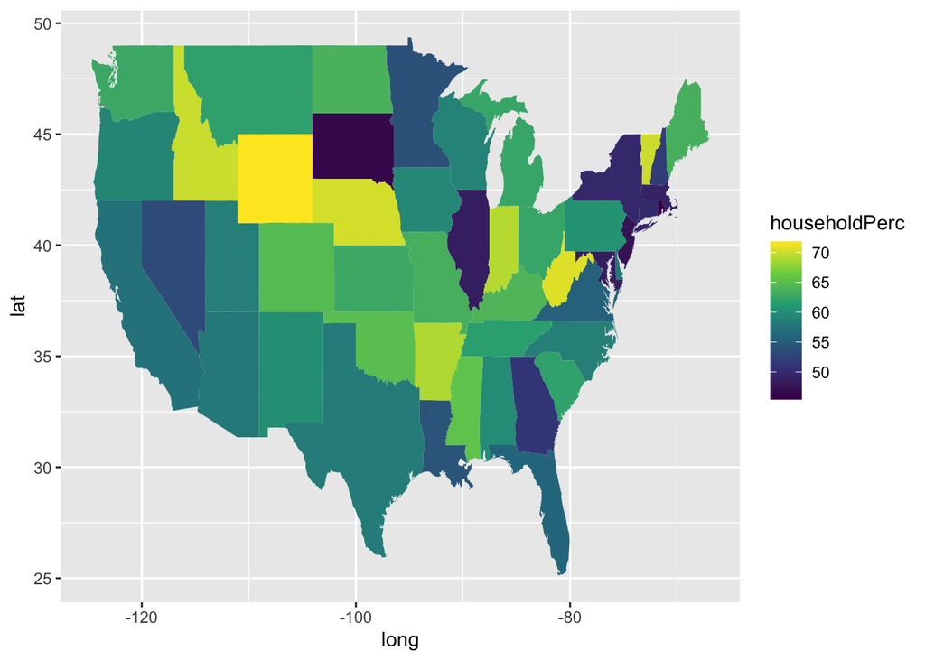

```r
household_graph <- ggplot(state_map_pets, aes(x= long, y = lat, group = group)) +
  geom_polygon(aes(fill = householdPerc)) +
  scale_fill_viridis_c() # Create map on total house percentage
household_graph # View graph
```

**Most states had a total household percentage of pets higher than 55%. With this, we can know that it is more common for a household in the United States to have a pet than to not.**

### 2. Boxplots comparing dog versus cat ownership in households

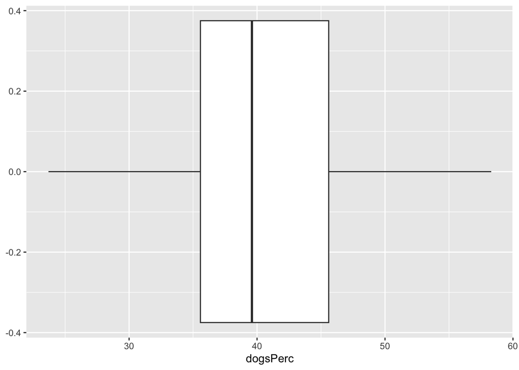

```r
ggplot(pet_data, aes(x=dogsPerc))+ geom_boxplot()
```

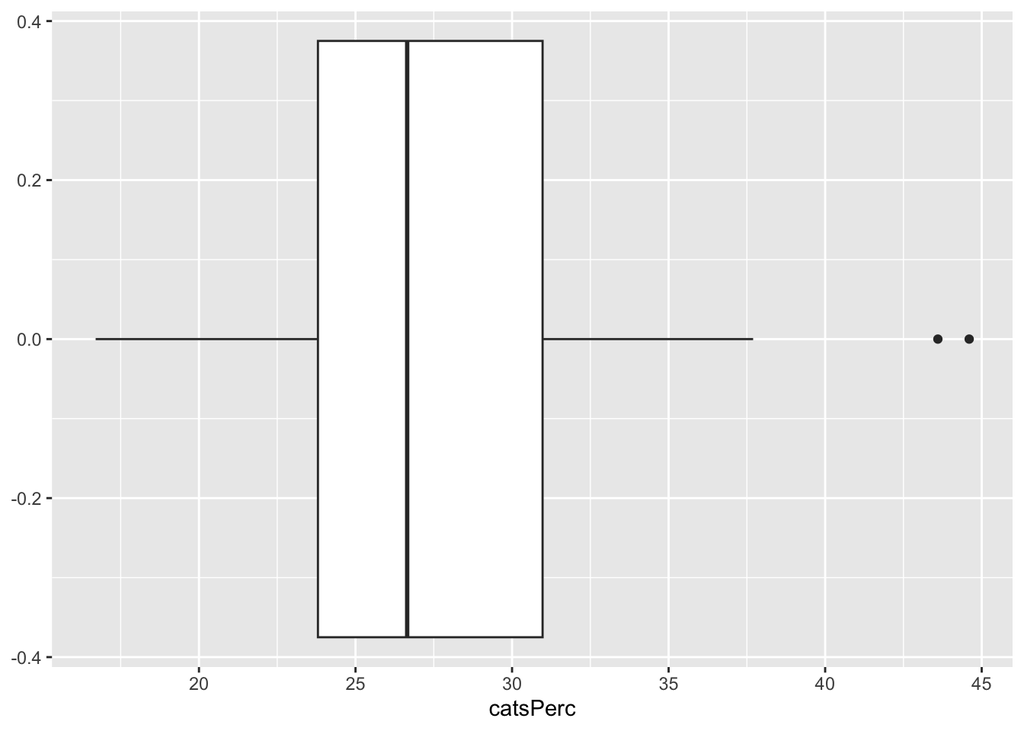

```r
ggplot(pet_data, aes(x=catsPerc))+ geom_boxplot()
```

**In both graphs we can see the distribution of higher percentages in the Dogs Percentages data; while the lower percentages are given to the Cats. The median for dogs would be just below 40; while for cats the median would be just above 25. This median interpretation means that the distribution of dogs’ percentages is higher than cats. This tells us the strong preference of people for owning dogs.**

### 3. Comparing dog devotion scores versus staying at a job they disliked and spending 4K to save their dog percentages

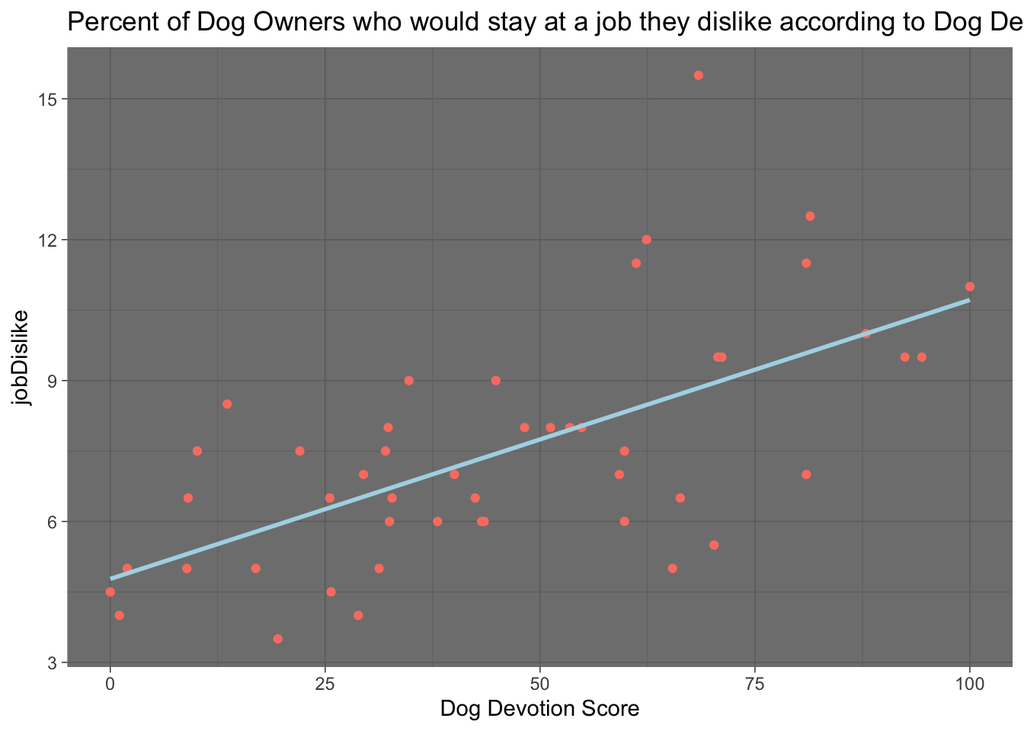

```r
ggplot(pet_data, aes(x = dogDevScore, y = jobDislikePerc))+
  geom_point(color="salmon") +
  stat_smooth(method = "lm", col="lightblue", se=FALSE ,size=1)+ #lm = linear regression
  labs(title = "Percent of Dog Owners who would stay at a job they dislike according to Dog Devotion Score", x = "Dog Devotion Score", y = "jobDislike") +
  theme_dark()
```

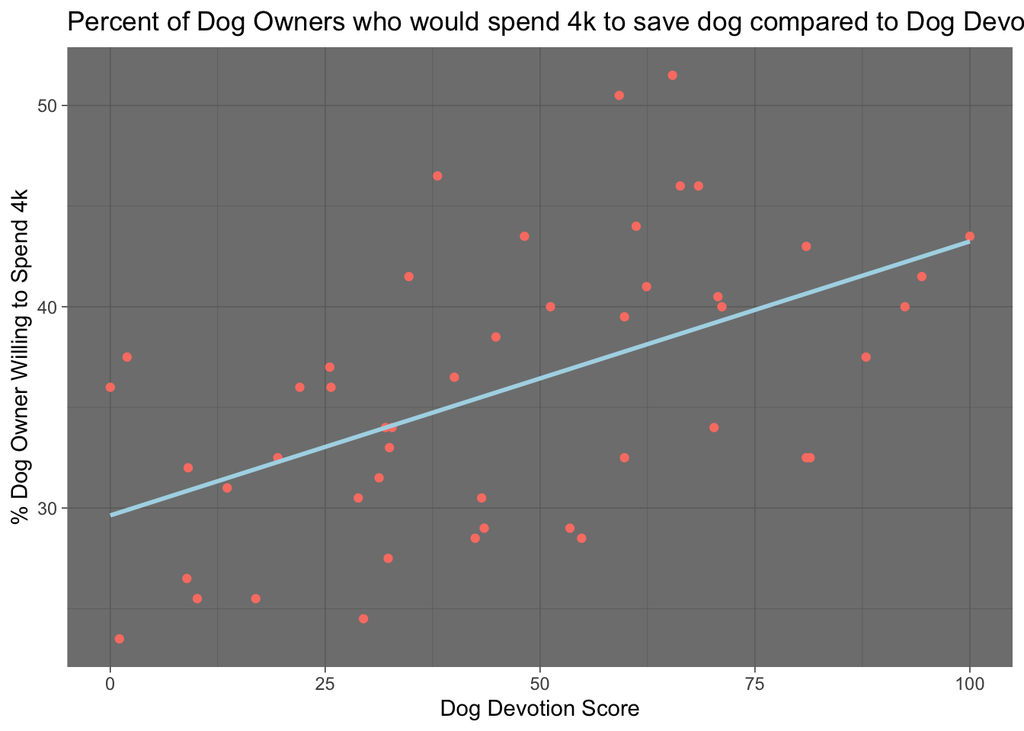

```r
ggplot(pet_data, aes(x = dogDevScore, y = spend4kPerc))+
  geom_point(color="salmon") +
  stat_smooth(method = "lm", col="lightblue", se=FALSE ,size=1)+ #lm = linear regression
  labs(title = "Percent of Dog Owners who would spend 4k to save dog compared to Dog Devotion Score", x = "Dog Devotion Score", y = "% Dog Owner Willing to Spend 4k") +
  theme_dark()
```

### 4. Comparing spacial correlation with areas where pet owners were willing to spend $4k to save their dog.

**We also created a heat map to see if there is any spatial correlation in states and areas where pet owners were willing to spend $4k to save their dog. For this section we pulled from another dataset to get the median household income per state. This was found here: https://worldpopulationreview.com/state-rankings/median-household-income-by-state**

```r
# Loading in the income into med_income
med_income <- read.csv(here("DATA","median-household-income-by-state-[updated-august-2023].csv"))
str(med_income)
```

```
## 'data.frame':    51 obs. of  2 variables:
##  $ state                    : chr  "Maryland" "District of Columbia" "Massachusetts" "New Jersey" ...
##  $ medianHouseholdIncome2021: int  90203 90088 89645 89296 88465 84907 84857 84247 83771 82254 ...
```

**Once again this data must be cleaned because it has data for DC, Alaska and Hawaii, and the columns need to be renamed to allow for it to be made into a map.**

```r
#Removes Alaska, Hawaii, and DC
med_income <- subset(med_income, state != "Alaska")
med_income <- subset(med_income, state != "Hawaii")
med_income <- subset(med_income, state != "District of Columbia")

# Renaming the columns for easier usage
colnames(med_income) <- c("region","income")

# Making all state names lower case
med_income$region <- tolower(med_income$region)
str(med_income)
```

```
## 'data.frame':    48 obs. of  2 variables:
##  $ region: chr  "maryland" "massachusetts" "new jersey" "new hampshire" ...
##  $ income: int  90203 89645 89296 88465 84907 84247 83771 82254 80963 79449 ...
```

**Now that the data has been cleaned, we can use it to create a map and compare it to. First, here is the map seeing the percentage of people that would spend 4K to save their dog.**

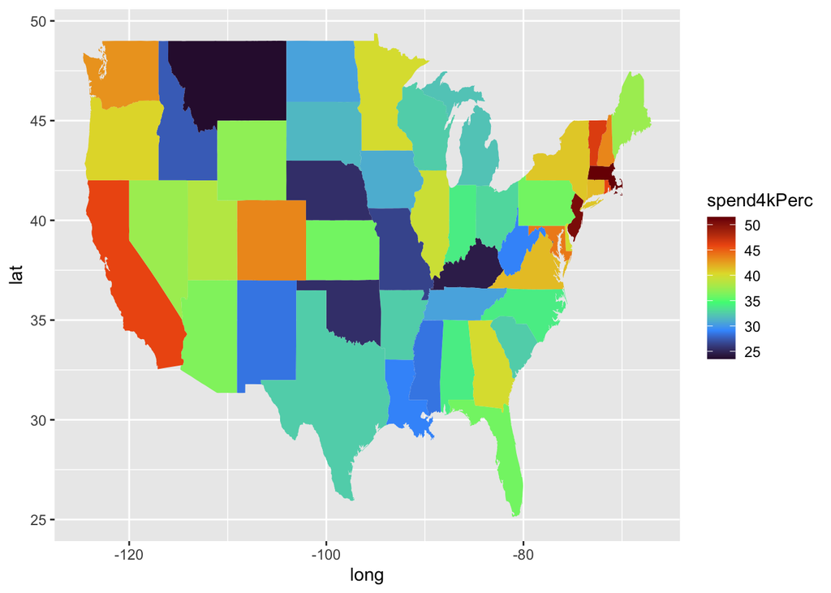

```r
# Joining data set with state map
state_map <- map_data("state")
state_map_pets <- left_join(state_map,pet_data, by = "region")

# Graph for the percentage of people that would pay 4k to save their dog
pay4kGraph <- ggplot(state_map_pets, aes(x= long, y = lat, group = group)) +
  geom_polygon(aes(fill = spend4kPerc)) +
  scale_fill_viridis_c(option = "turbo")
pay4kGraph
```

**Next we’ll plot the median income per state**

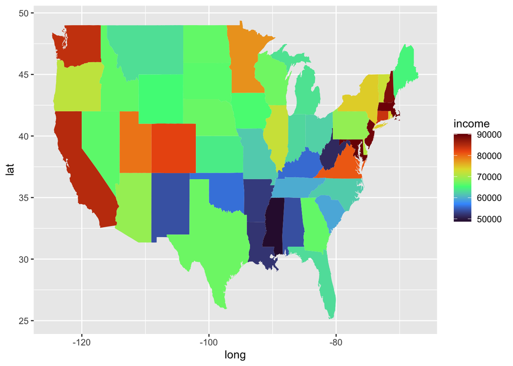

```r
# Joining data set with state map
state_map_med <- left_join(state_map,med_income, by = "region")

# Graph for the percentage of people that would pay 4k to save their dog
medGraph <- ggplot(state_map_med, aes(x= long, y = lat, group = group)) +
  geom_polygon(aes(fill = income)) +
  scale_fill_viridis_c(option = "turbo")
medGraph
```

**There is some correlation between the two maps. States with higher incomes such as California, Massachusetts, and New Jersey also have higher percentages of people that would spend $4K to save their dogs. Similarly, states with lower income like New Mexico, Arkansas, and Oklahoma were less likely to save their dog for $4K. This suggests that there is a correlation between median incomes and people’s willingness/ability to spend $4K to save their dog.**

## General Conclusion

**1. Our pet ownership statistics data set had enough data to accurately answer all of our questions.**